# Practical Machine Learning Course Project

E.Dobrogodin

23 July 2015 г.

### Background

Using devices such as Jawbone Up, Nike FuelBand, and Fitbit it is now possible to collect a large amount of data about personal activity relatively inexpensively. These type of devices are part of the quantified self movement – a group of enthusiasts who take measurements about themselves regularly to improve their health, to find patterns in their behavior, or because they are tech geeks. One thing that people regularly do is quantify how much of a particular activity they do, but they rarely quantify how well they do it. In this project, your goal will be to use data from accelerometers on the belt, forearm, arm, and dumbell of 6 participants. They were asked to perform barbell lifts correctly and incorrectly in 5 different ways. More information is available from the website here: http://groupware.les.inf.puc-rio.br/har (see the section on the Weight Lifting Exercise Dataset).

## Loading data

First, set working directory in your R command line. Then, download *train* and *test* data to R.

```r
train <- read.csv('pml-training.csv', na.strings=c("NA","#DIV/0!", ""))
test <- read.csv('pml-testing.csv' , na.strings=c("NA", "#DIV/0!", ""))
```

Since the data set have a lot of missing data, we need to preprocess data.

```r
# remove columns with a lot of NA values
goodVars <- which((colSums(!is.na(train)) >= 0.6*nrow(train)))
train <- train[,goodVars]
test <- test[,goodVars]

# remove problem id
test <- test[-ncol(test)]
# fix factor levels
test$new_window <- factor(test$new_window, levels=c("no","yes"))

#Remove X and cvtd_timestamp colums from the dataset since they are not relevant
train <- train[,-c(1,5)]
test <- test[,-c(1,5)]
```

## Building the model.

The goal of project is to predict the manner in which participants did the exercise. This is the *classe* variable in the training set (Factor variable with 5 levels A, B, C, D, E).

### CART model

The first model for prediction will be CART model or Classification and Regression Tree. Let’s build the model and plot the tree, to see how classification is made.

```r
library(rpart)
library(rpart.plot)
```

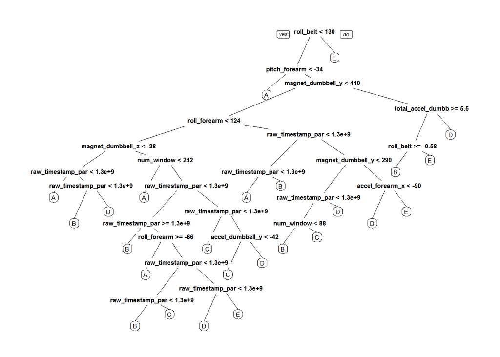

```r
modelCART <- rpart(classe ~ ., data = train)
# we can plot the tree to see how classification is working
prp(modelCART)
```

Now, let’s make predictions for test set.

```r
#predictions for the test set
predictCART <- predict(modelCART, newdata = test)

test$classe <- NULL
for (i in 1:length(test[,1])) {
        test$classe[i] <- names(which.max(predictCART[i,]))
}
as.factor(test$classe)
```

```
##  [1] B A E A A C D E A A C E B A E E A A B B
## Levels: A B C D E
```

## Random Forest

The second model is Random Forest.

```r
library(randomForest)
```

```r
modelRF <- randomForest(classe ~ ., data=train)
test$classe <- predict(modelRF, newdata = test)
test$classe
```

```
##  [1] B A B A A E D B A A B C B A E E A B B B
## Levels: A B C D E
```

### Results.

One can see that there is a difference in resulsts for CART model and Random Forests. It has to do with the fact that CART model has larger prediction error. All results was submitted in different part of this course project.